# MT_Project_LearnerNotebook_FullCode

#### Grid Search CV

```python
%%time

# defining model
Model = XGBClassifier(random_state=1,eval_metric='logloss')

#Parameter grid to pass in RandomSearchCV
param_grid={'n_estimators':[150,200,250],'scale_pos_weight':[5,10], 'learning_rate':[0.1,0.2], 'gamma':[0,3,5], 'subsample':[0.8,0.9]}

#Calling RandomizedSearchCV
randomized_cv = GridSearchCV(estimator=Model, param_grid=param_grid, n_jobs = -1, scoring=scorer, cv=5)

#Fitting parameters in RandomizedSearchCV
randomized_cv.fit(X_train,y_train)

print("Best parameters are {} with CV score={}:" .format(randomized_cv.best_params_,randomized_cv.best_score_))
```

```
Best parameters are {'gamma': 5, 'learning_rate': 0.2, 'n_estimators': 200, 'scale_pos_weight': 10, 'subsample': 0.8} with CV score=0.8582136930957363:
CPU times: total: 5.02 s
Wall time: 5min 5s
```

```python
%%time

# defining model
Model = XGBClassifier(random_state=1,eval_metric='logloss')

#Parameter grid to pass in RandomSearchCV
param_grid={'n_estimators':[150,200,250],'scale_pos_weight':[5,10], 'learning_rate':[0.1,0.2], 'gamma':[0,3,5], 'subsample':[0.8,0.9]}

#Calling RandomizedSearchCV
randomized_cv = GridSearchCV(estimator=Model, param_grid=param_grid, n_jobs = -1, scoring=scorer, cv=5)

#Fitting parameters in RandomizedSearchCV
randomized_cv.fit(X_train_over,y_train_over)

print("Best parameters are {} with CV score={}:" .format(randomized_cv.best_params_,randomized_cv.best_score_))
```

```
Best parameters are {'gamma': 0, 'learning_rate': 0.1, 'n_estimators': 250, 'scale_pos_weight': 10, 'subsample': 0.9} with CV score=0.9961181368591415:
CPU times: total: 37.8 s
Wall time: 8min 28s
```

```python
# Creating new pipeline with best parameters
tuned_xgb1 = XGBClassifier(
    max_features=0.7,
    random_state=1,
    learning_rate=1,
    n_estimators=50,
    subsample=0.2
)

tuned_xgb1.fit(X_train, y_train)
```

```
XGBClassifier(base_score=None, booster=None, callbacks=None,
              colsample_bylevel=None, colsample_bynode=None,
              colsample_bytree=None, device=None, early_stopping_rounds=None,
              enable_categorical=False, eval_metric=None, feature_types=None,
              gamma=None, grow_policy=None, importance_type=None,
              interaction_constraints=None, learning_rate=1, max_bin=None,
              max_cat_threshold=None, max_cat_to_onehot=None,
              max_delta_step=None, max_depth=None, max_features=0.7,
              max_leaves=None, min_child_weight=None, missing=nan,
              monotone_constraints=None, multi_strategy=None, n_estimators=50,
              n_jobs=None, num_parallel_tree=None, ...)
```

```python
xgb_grid_train = model_performance_classification_sklearn(
    tuned_xgb1, X_train, y_train
)
xgb_grid_train
```

|  | Accuracy | Recall | Precision | F1 |
| --- | --- | --- | --- | --- |
| 0 | 0.984 | 0.871 | 0.849 | 0.860 |

```python
xgb_grid_val = model_performance_classification_sklearn(tuned_xgb1, X_val, y_val)
xgb_grid_val
```

|  | Accuracy | Recall | Precision | F1 |
| --- | --- | --- | --- | --- |
| 0 | 0.972 | 0.777 | 0.740 | 0.758 |

```python
# Creating new pipeline with best parameters
tuned_xgb1_over = XGBClassifier(
    max_features=0.7,
    random_state=1,
    learning_rate=1,
    n_estimators=50,
    subsample=0.2
)

tuned_xgb1_over.fit(X_train_over, y_train_over)
```

```
XGBClassifier(base_score=None, booster=None, callbacks=None,
              colsample_bylevel=None, colsample_bynode=None,
              colsample_bytree=None, device=None, early_stopping_rounds=None,
              enable_categorical=False, eval_metric=None, feature_types=None,
              gamma=None, grow_policy=None, importance_type=None,
              interaction_constraints=None, learning_rate=1, max_bin=None,
              max_cat_threshold=None, max_cat_to_onehot=None,
              max_delta_step=None, max_depth=None, max_features=0.7,
              max_leaves=None, min_child_weight=None, missing=nan,
              monotone_constraints=None, multi_strategy=None, n_estimators=50,
              n_jobs=None, num_parallel_tree=None, ...)
```

```python
xgb_grid_over = model_performance_classification_sklearn(
    tuned_xgb1_over, X_train_over, y_train_over
)
xgb_grid_over
```

|  | Accuracy | Recall | Precision | F1 |
| --- | --- | --- | --- | --- |
| 0 | 0.984 | 0.986 | 0.982 | 0.984 |

```python
xgb_grid_val_over = model_performance_classification_sklearn(tuned_xgb1_over, X_val, y_val)
xgb_grid_val_over
```

|  | Accuracy | Recall | Precision | F1 |
| --- | --- | --- | --- | --- |
| 0 | 0.953 | 0.856 | 0.550 | 0.669 |

```python
# Creating new pipeline with best parameters
tuned_xgb1_un = XGBClassifier(
    max_features=0.7,
    random_state=1,
    learning_rate=1,
    n_estimators=50,
    subsample=0.2
)

tuned_xgb1_un.fit(X_train_un, y_train_un)
```

```
XGBClassifier(base_score=None, booster=None, callbacks=None,
              colsample_bylevel=None, colsample_bynode=None,
              colsample_bytree=None, device=None, early_stopping_rounds=None,
              enable_categorical=False, eval_metric=None, feature_types=None,
              gamma=None, grow_policy=None, importance_type=None,
              interaction_constraints=None, learning_rate=1, max_bin=None,
              max_cat_threshold=None, max_cat_to_onehot=None,
              max_delta_step=None, max_depth=None, max_features=0.7,
              max_leaves=None, min_child_weight=None, missing=nan,
              monotone_constraints=None, multi_strategy=None, n_estimators=50,
              n_jobs=None, num_parallel_tree=None, ...)
```

```python
xgb_grid_un= model_performance_classification_sklearn(
    tuned_xgb1_over, X_train_un, y_train_un
)
xgb_grid_un
```

|  | Accuracy | Recall | Precision | F1 |
| --- | --- | --- | --- | --- |
| 0 | 0.981 | 0.983 | 0.980 | 0.981 |

```python
xgb_grid_val_un = model_performance_classification_sklearn(tuned_xgb1_un, X_val, y_val)
xgb_grid_val_un
```

|  | Accuracy | Recall | Precision | F1 |
| --- | --- | --- | --- | --- |
| 0 | 0.799 | 0.853 | 0.197 | 0.320 |

### Sample tuning method for Decision tree with original data

```python
# defining model
Model = DecisionTreeClassifier(random_state=1)

# Parameter grid to pass in RandomSearchCV
param_grid = {'max_depth': np.arange(2,6),
              'min_samples_leaf': [1, 4, 7],
              'max_leaf_nodes' : [10,15],
              'min_impurity_decrease': [0.0001,0.001] }

#Calling RandomizedSearchCV
randomized_cv = RandomizedSearchCV(estimator=Model, param_distributions=param_grid, n_iter=10, n_jobs = -1, scoring=scorer, cv=5, random_state=1)

#Fitting parameters in RandomizedSearchCV
randomized_cv.fit(X_train,y_train)

print("Best parameters are {} with CV score={}:" .format(randomized_cv.best_params_,randomized_cv.best_score_))
```

```
Best parameters are {'min_samples_leaf': 7, 'min_impurity_decrease': 0.0001, 'max_leaf_nodes': 15, 'max_depth': 5} with CV score=0.5684366207344347:
```

```python
# Creating new pipeline with best parameters
tuned_dt = DecisionTreeClassifier(
    max_features=0.7,
    random_state=1,
     max_depth=10,
    min_samples_split=5

)

tuned_dt.fit(X_train, y_train)
```

```
DecisionTreeClassifier(max_depth=10, max_features=0.7, min_samples_split=5,
                       random_state=1)
```

```python
dt_random_train = model_performance_classification_sklearn(
    tuned_dt, X_train, y_train
)
dt_random_train
```

|  | Accuracy | Recall | Precision | F1 |
| --- | --- | --- | --- | --- |
| 0 | 0.985 | 0.737 | 0.995 | 0.847 |

```python
dt_random_val = model_performance_classification_sklearn(tuned_dt, X_val, y_val)
dt_random_val
```

|  | Accuracy | Recall | Precision | F1 |
| --- | --- | --- | --- | --- |
| 0 | 0.976 | 0.637 | 0.903 | 0.747 |

#### Observation

- We have received the Recall score of 0.73 and 0.63 on the training and validation set, respectively.

### Sample tuning method for Decision tree with oversampled data

```python
# defining model
Model = DecisionTreeClassifier(random_state=1)

# Parameter grid to pass in RandomSearchCV
param_grid = {'max_depth': np.arange(2,6),
              'min_samples_leaf': [1, 4, 7],
              'max_leaf_nodes' : [10,15],
              'min_impurity_decrease': [0.0001,0.001] }

#Calling RandomizedSearchCV
randomized_cv = RandomizedSearchCV(estimator=Model, param_distributions=param_grid, n_iter=10, n_jobs = -1, scoring=scorer, cv=5, random_state=1)

#Fitting parameters in RandomizedSearchCV
randomized_cv.fit(X_train_over,y_train_over)

print("Best parameters are {} with CV score={}:" .format(randomized_cv.best_params_,randomized_cv.best_score_))
```

```
Best parameters are {'min_samples_leaf': 7, 'min_impurity_decrease': 0.001, 'max_leaf_nodes': 15, 'max_depth': 3} with CV score=0.9102913265648006:
```

```python
# Creating new pipeline with best parameters
tuned_dt_over = DecisionTreeClassifier(
    max_features=0.7,
    random_state=1,
     max_depth=10,
    min_samples_split=5

)

tuned_dt_over.fit(X_train_over, y_train_over)
```

```
DecisionTreeClassifier(max_depth=10, max_features=0.7, min_samples_split=5,
                       random_state=1)
```

```python
dt_random_over = model_performance_classification_sklearn(
    tuned_dt_over, X_train_over, y_train_over
)
dt_random_over
```

|  | Accuracy | Recall | Precision | F1 |
| --- | --- | --- | --- | --- |
| 0 | 0.957 | 0.946 | 0.967 | 0.956 |

```python
dt_random_val_over = model_performance_classification_sklearn(tuned_dt_over, X_val, y_val)
dt_random_val_over
```

|  | Accuracy | Recall | Precision | F1 |
| --- | --- | --- | --- | --- |
| 0 | 0.942 | 0.806 | 0.485 | 0.605 |

### Sample tuning method for Decision tree with undersampled data

```python
# defining model
Model = DecisionTreeClassifier(random_state=1)

# Parameter grid to pass in RandomSearchCV
param_grid = {'max_depth': np.arange(2,20),
              'min_samples_leaf': [1, 2, 5, 7],
              'max_leaf_nodes' : [5, 10,15],
              'min_impurity_decrease': [0.0001,0.001] }

#Calling RandomizedSearchCV
randomized_cv = RandomizedSearchCV(estimator=Model, param_distributions=param_grid, n_iter=10, n_jobs = -1, scoring=scorer, cv=5, random_state=1)

#Fitting parameters in RandomizedSearchCV
randomized_cv.fit(X_train_un,y_train_un)

print("Best parameters are {} with CV score={}:" .format(randomized_cv.best_params_,randomized_cv.best_score_))
```

```
Best parameters are {'min_samples_leaf': 1, 'min_impurity_decrease': 0.001, 'max_leaf_nodes': 5, 'max_depth': 2} with CV score=0.850811629752543:
```

```python
# Creating new pipeline with best parameters
tuned_dt_un = DecisionTreeClassifier(
    max_features=0.7,
    random_state=1,
     max_depth=10,
    min_samples_split=5

)

tuned_dt_un.fit(X_train_un, y_train_un)
```

```
DecisionTreeClassifier(max_depth=10, max_features=0.7, min_samples_split=5,
                       random_state=1)
```

```python
dt_random_un = model_performance_classification_sklearn(
    tuned_dt_un, X_train_un, y_train_un
)
dt_random_un
```

|  | Accuracy | Recall | Precision | F1 |
| --- | --- | --- | --- | --- |
| 0 | 0.956 | 0.924 | 0.986 | 0.954 |

```python
dt_random_val_un = model_performance_classification_sklearn(tuned_dt_un, X_val, y_val)
dt_random_val_un
```

|  | Accuracy | Recall | Precision | F1 |
| --- | --- | --- | --- | --- |
| 0 | 0.899 | 0.845 | 0.338 | 0.483 |

#### Observation

- The Decisiontree model on randomsearchCV generalizing well on both undersampled and validation datasets
- The validation recall is 92% and ~84% i.e. the model is good at identifying potential customers who would take the offer.

### GridSearch CV

### Sample tuning method for Decision tree with original data

```python
# defining model
Model = DecisionTreeClassifier(random_state=1)

# Parameter grid to pass in RandomSearchCV
param_grid = {'max_depth': np.arange(2,6),
              'min_samples_leaf': [1, 4, 7],
              'max_leaf_nodes' : [10,15],
              'min_impurity_decrease': [0.0001,0.001] }

#Calling GridSearchCV
randomized_cv = GridSearchCV(estimator=Model, param_grid=param_grid,  n_jobs = -1, scoring=scorer, cv=5)

#Fitting parameters in RandomizedSearchCV
randomized_cv.fit(X_train,y_train)

print("Best parameters are {} with CV score={}:" .format(randomized_cv.best_params_,randomized_cv.best_score_))
```

```
Best parameters are {'max_depth': 5, 'max_leaf_nodes': 15, 'min_impurity_decrease': 0.0001, 'min_samples_leaf': 1} with CV score=0.5756511074237067:
```

```python
# Creating new pipeline with best parameters
tuned_dt1 = DecisionTreeClassifier(
    max_features=0.7,
    random_state=1,
    max_depth=10,
    min_samples_split=5
)

tuned_dt1.fit(X_train, y_train)
```

```
DecisionTreeClassifier(max_depth=10, max_features=0.7, min_samples_split=5,
                       random_state=1)
```

```python
gt_grid_train = model_performance_classification_sklearn(
    tuned_dt1, X_train, y_train
)
gt_grid_train
```

|  | Accuracy | Recall | Precision | F1 |
| --- | --- | --- | --- | --- |
| 0 | 0.985 | 0.737 | 0.995 | 0.847 |

```python
gt_grid_val = model_performance_classification_sklearn(tuned_dt1, X_val, y_val)
gt_grid_val
```

|  | Accuracy | Recall | Precision | F1 |
| --- | --- | --- | --- | --- |
| 0 | 0.976 | 0.637 | 0.903 | 0.747 |

#### Observation

- We have received the Recall score of 0.73 and 0.63 on the training and validation set, respectively.

### Sample tuning method for Decision tree with oversampled data

```python
# defining model
Model = DecisionTreeClassifier(random_state=1)

# Parameter grid to pass in RandomSearchCV
param_grid = {'max_depth': np.arange(2,6),
              'min_samples_leaf': [1, 4, 7],
              'max_leaf_nodes' : [10,15],
              'min_impurity_decrease': [0.0001,0.001] }

#Calling GridSearchCV
randomized_cv = GridSearchCV(estimator=Model, param_grid=param_grid,  n_jobs = -1, scoring=scorer, cv=5)

#Fitting parameters in RandomizedSearchCV
randomized_cv.fit(X_train_over,y_train_over)

print("Best parameters are {} with CV score={}:" .format(randomized_cv.best_params_,randomized_cv.best_score_))
```

```
Best parameters are {'max_depth': 3, 'max_leaf_nodes': 10, 'min_impurity_decrease': 0.0001, 'min_samples_leaf': 1} with CV score=0.9102913265648006:
```

```python
# Creating new pipeline with best parameters
tuned_dt1_over = DecisionTreeClassifier(
    max_features=0.7,
    random_state=1,
    max_depth=10,
    min_samples_split=5
)

tuned_dt1_over.fit(X_train_over, y_train_over)
```

```
DecisionTreeClassifier(max_depth=10, max_features=0.7, min_samples_split=5,
                       random_state=1)
```

```python
gt_grid_over = model_performance_classification_sklearn(
    tuned_dt1_over, X_train_over, y_train_over
)
gt_grid_over
```

|  | Accuracy | Recall | Precision | F1 |
| --- | --- | --- | --- | --- |
| 0 | 0.957 | 0.946 | 0.967 | 0.956 |

```python
gt_grid_val_over = model_performance_classification_sklearn(tuned_dt1_over, X_val, y_val)
gt_grid_val_over
```

|  | Accuracy | Recall | Precision | F1 |
| --- | --- | --- | --- | --- |
| 0 | 0.942 | 0.806 | 0.485 | 0.605 |

#### Observation

- The Decisiontree model on gridsearchCV generalizing well on both oversampled and validation datasets
- The validation recall is 94% and ~80% i.e. the model is good at identifying potential customers who would take the offer.

### Sample tuning method for Decision tree with undersampled data

```python
# defining model
Model = DecisionTreeClassifier(random_state=1)

# Parameter grid to pass in RandomSearchCV
param_grid = {'max_depth': np.arange(2,6),
              'min_samples_leaf': [1, 4, 7],
              'max_leaf_nodes' : [10,15],
              'min_impurity_decrease': [0.0001,0.001] }

#Calling GridSearchCV
randomized_cv = GridSearchCV(estimator=Model, param_grid=param_grid,  n_jobs = -1, scoring=scorer, cv=5)

#Fitting parameters in RandomizedSearchCV

print("Best parameters are {} with CV score={}:" .format(randomized_cv.best_params_,randomized_cv.best_score_))
```

[output not shown]

```python
# Creating new pipeline with best parameters
tuned_dt1_un = DecisionTreeClassifier(
    max_features=0.7,
    random_state=1,
    max_depth=10,
    min_samples_split=5
)

tuned_dt1_un.fit(X_train_un, y_train_un)
```

```
DecisionTreeClassifier(max_depth=10, max_features=0.7, min_samples_split=5,
                       random_state=1)
```

```python
gt_grid_un = model_performance_classification_sklearn(
    tuned_dt1_un, X_train_un, y_train_un
)
gt_grid_un
```

|  | Accuracy | Recall | Precision | F1 |
| --- | --- | --- | --- | --- |
| 0 | 0.956 | 0.924 | 0.986 | 0.954 |

```python
gt_grid_val_un = model_performance_classification_sklearn(tuned_dt1_un, X_val, y_val)
gt_grid_val_un
```

|  | Accuracy | Recall | Precision | F1 |
| --- | --- | --- | --- | --- |
| 0 | 0.899 | 0.845 | 0.338 | 0.483 |

#### Observation

- The Decisiontree model on gridsearchCV generalizing well on both undersampled and validation datasets
- The validation recall is 92% and ~845% i.e. the model is good at identifying potential customers who would take the offer.

## Model performance comparison and choosing the final model

```python
# training performance comparison

models_train_comp_df = pd.concat(
    [
       gbc_random_train.T,
       gbc_random_over.T,
       gbc_random_un.T,
       gbm_grid_train.T,
       rf_random_train.T,
        rf_random_over.T,
        rf_random_un.T,
       rf3_grid_train.T,
       rf3_grid_over.T,
      rf3_grid_un.T,
      xgb_random_train.T,
      xgb_random_over.T,
     xgb_random_un.T,
     xgb_grid_train.T,
     xgb_grid_over.T,
     xgb_grid_un.T,
     dt_random_train.T,
     dt_random_over.T,
     dt_random_un.T,
     gt_grid_train.T,
     gt_grid_over.T,
     gt_grid_un.T

    ],
    axis=1,
)
models_train_comp_df.columns = [

    "Gradient Boosting Tuned with Random search using train data",
    "Gradient Boosting Tuned with Random search using oversampled data",
    "Gradient Boosting Tuned with Random search using undersampled data",
    "Gradient Boosting Tuned with grid search using train data",
    "RandomForest Tuned with Random search using TrainData",
    "RandomForest Tuned with Random search using overSampledData",
    "RandomForest Tuned with Random search using underSampledData",
     "RandomForest Tuned with GridSearch using TrainData",
    "RandomForest Tuned with GridSearch using overSampledData",
    "RandomForest Tuned with GridSearch using underSampledData",
    "XGB Classifier Tuned with RandomSearch using TrainData",
    "XGB Classifier Tuned with RandomSearch using OverSampledData",
    "XGB Classifier Tuned with RandomSearch using UnderSampledData",
    "XGB Classifier Tuned with GridSearch using Train Data",
    "XGB Classifier Tuned with GridSearch using OverSampledData",
    "XGB Classifier Tuned with GridSearch using UnderSampledData",
    "Decition tree Tuned with RandomSearch using TrainData",
    "Decition tree Tuned with RandomSearch using OverSampledData",
    "Decition tree Tuned with RandomSearch using UnderSampedData",
    "Decition tree Tuned with GridSearch using TrainData",
    "Decition tree Tuned with GridSearch using OverSampledData",
    "Decition tree Tuned with GridSearch using UnderSampledData"

]
print("Training performance comparison:")
models_train_comp_df
```

```
Training performance comparison:
```

|  | Gradient Boosting Tuned with Random search using train data | Gradient Boosting Tuned with Random search using oversampled data | Gradient Boosting Tuned with Random search using undersampled data | Gradient Boosting Tuned with grid search using train data | RandomForest Tuned with Random search using TrainData | RandomForest Tuned with Random search using overSampledData | RandomForest Tuned with Random search using underSampledData | RandomForest Tuned with GridSearch using TrainData | RandomForest Tuned with GridSearch using overSampledData | RandomForest Tuned with GridSearch using underSampledData | XGB Classifier Tuned with RandomSearch using TrainData | XGB Classifier Tuned with RandomSearch using OverSampledData | XGB Classifier Tuned with RandomSearch using UnderSampledData | XGB Classifier Tuned with GridSearch using Train Data | XGB Classifier Tuned with GridSearch using OverSampledData | XGB Classifier Tuned with GridSearch using UnderSampledData | Decition tree Tuned with RandomSearch using TrainData | Decition tree Tuned with RandomSearch using OverSampledData | Decition tree Tuned with RandomSearch using UnderSampedData | Decition tree Tuned with GridSearch using TrainData | Decition tree Tuned with GridSearch using OverSampledData | Decition tree Tuned with GridSearch using UnderSampledData |
| --- | --- | --- | --- | --- | --- | --- | --- | --- | --- | --- | --- | --- | --- | --- | --- | --- | --- | --- | --- | --- | --- | --- |
| Accuracy | 0.966 | 0.947 | 0.742 | 0.966 | 0.995 | 1.000 | 0.990 | 0.995 | 1.000 | 0.990 | 0.984 | 0.984 | 0.907 | 0.984 | 0.984 | 0.981 | 0.985 | 0.957 | 0.956 | 0.985 | 0.957 | 0.956 |
| Recall | 0.617 | 0.943 | 0.692 | 0.617 | 0.907 | 0.999 | 0.980 | 0.907 | 0.999 | 0.980 | 0.871 | 0.986 | 0.913 | 0.871 | 0.986 | 0.983 | 0.737 | 0.946 | 0.924 | 0.737 | 0.946 | 0.924 |
| Precision | 0.727 | 0.951 | 0.768 | 0.727 | 1.000 | 1.000 | 1.000 | 1.000 | 1.000 | 1.000 | 0.849 | 0.982 | 0.902 | 0.849 | 0.982 | 0.980 | 0.995 | 0.967 | 0.986 | 0.995 | 0.967 | 0.986 |
| F1 | 0.667 | 0.947 | 0.728 | 0.667 | 0.951 | 1.000 | 0.990 | 0.951 | 1.000 | 0.990 | 0.860 | 0.984 | 0.907 | 0.860 | 0.984 | 0.981 | 0.847 | 0.956 | 0.954 | 0.847 | 0.956 | 0.954 |

```python
# training performance comparison

models_val_comp_df = pd.concat(
    [
       gbc_random_val.T,
      gbc_random_val_over.T,
      gbc_random_val_un.T,
      gbm_grid_val.T,
      rf_random_val.T,
        rf_random_val_over.T,
        rf_random_val_un.T,
       rf3_grid_val.T,
       rf3_grid_val_over.T,
      rf3_grid_val_un.T,
      xgb_random_val.T,
      xgb_random_val_over.T,
     xgb_random_val_un.T,
     xgb_grid_val.T,
     xgb_grid_val_over.T,
     xgb_grid_val_un.T,
     dt_random_val.T,
     dt_random_val_over.T,
     dt_random_val_un.T,
     gt_grid_val.T,
     gt_grid_val_over.T,
     gt_grid_val_un.T

    ],
    axis=1,
)
models_val_comp_df.columns = [
   "Gradient Boosting Tuned with Random search using train data",
    "Gradient Boosting Tuned with Random search using oversampled data",
    "Gradient Boosting Tuned with Random search using undersampled data",
    "Gradient Boosting Tuned with grid search using train data",
    "RandomForest Tuned with Random search using TrainData",
    "RandomForest Tuned with Random search using overSampledData",
    "RandomForest Tuned with Random search using underSampledData",
     "RandomForest Tuned with GridSearch using TrainData",
    "RandomForest Tuned with GridSearch using overSampledData",
    "RandomForest Tuned with GridSearch using underSampledData",
    "XGB Classifier Tuned with RandomSearch using TrainData",
    "XGB Classifier Tuned with RandomSearch using OverSampledData",
    "XGB Classifier Tuned with RandomSearch using UnderSampledData",
    "XGB Classifier Tuned with GridSearch using Train Data",
    "XGB Classifier Tuned with GridSearch using OverSampledData",
    "XGB Classifier Tuned with GridSearch using UnderSampledData",
    "Decition tree Tuned with RandomSearch using TrainData",
    "Decition tree Tuned with RandomSearch using OverSampledData",
    "Decition tree Tuned with RandomSearch using UnderSampedData",
    "Decition tree Tuned with GridSearch using TrainData",
    "Decition tree Tuned with GridSearch using OverSampledData",
    "Decition tree Tuned with GridSearch using UnderSampledData"


]
print("Training performance comparison:")
models_val_comp_df
```

```
Training performance comparison:
```

[output not shown]

- The Random forest classifier model tuned using Random Search and Grid search is giving the best validation recall of 0.888 but it has the low values of validation precision.
- Let's check the model's performance on test set and then see the feature importance from the tuned Random forest

### Test set final performance

```python
# Calculating different metrics on the test set
rf_grid_test = model_performance_classification_sklearn(tuned_rf3, X_test, Y_test)
print("Test performance:")
rf_grid_test
```

```
Test performance:
```

|  | Accuracy | Recall | Precision | F1 |
| --- | --- | --- | --- | --- |
| 0 | 0.983 | 0.702 | 0.985 | 0.820 |

- The model demonstrates strong overall performance with high accuracy and precision, and a good balance between precision and recall as indicated by the F1 score.
- While the model is reliable, there is room to improve recall, which could be beneficial in applications where capturing all positive instances is critical.

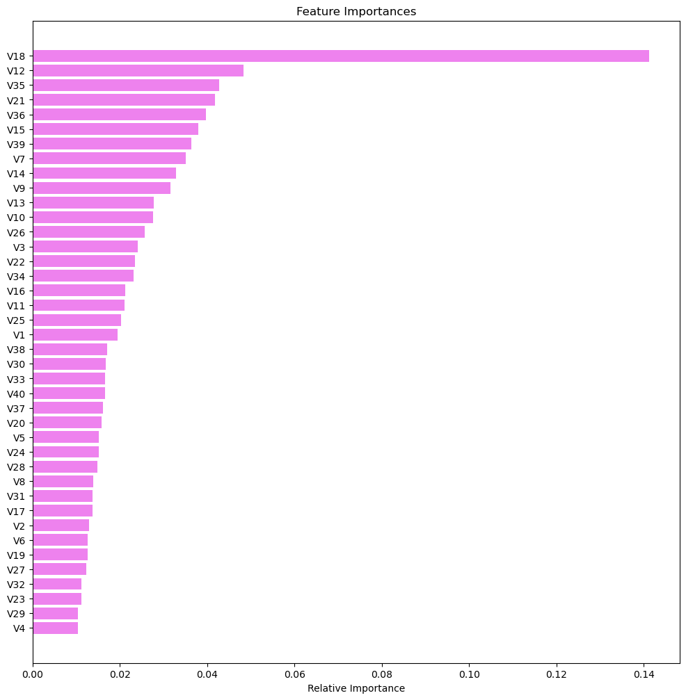

```python
feature_names = X.columns
importances = tuned_rf3.feature_importances_
indices = np.argsort(importances)

plt.figure(figsize=(12, 12))
plt.title("Feature Importances")
plt.barh(range(len(indices)), importances[indices], color="violet", align="center")
plt.yticks(range(len(indices)), [feature_names[i] for i in indices])
plt.xlabel("Relative Importance")
plt.show()
```

The most important feature is V18 followed by V12 and V35.

## Pipelines to build the final model

```python
Pipeline_model = Pipeline([
    ('scaler', StandardScaler()),  # Example preprocessing step, remove if not needed
    ('classifier', RandomForestClassifier(
        max_features='sqrt',  # Example parameter, adjust based on your tuning results
        random_state=1,
        max_samples=0.8,
        n_estimators=100,
        min_samples_leaf=2
    ))
])

# Fit the pipeline model on the training data
Pipeline_model.fit(X_train, y_train)
```

```
Pipeline(steps=[('scaler', StandardScaler()),
                ('classifier',
                 RandomForestClassifier(max_samples=0.8, min_samples_leaf=2,
                                        random_state=1))])
```

```python
# Let's check the performance on test set
Model_test = model_performance_classification_sklearn(Pipeline_model, X_test, Y_test)
Model_test
```

|  | Accuracy | Recall | Precision | F1 |
| --- | --- | --- | --- | --- |
| 0 | 0.981 | 0.670 | 0.984 | 0.797 |

- Recall is 67 so we try oversampling

```python
Pipeline_model_over = Pipeline([
    ('scaler', StandardScaler()),  # Example preprocessing step, remove if not needed
    ('classifier', RandomForestClassifier(
        max_features='sqrt',  # Example parameter, adjust based on your tuning results
        random_state=1,
        max_samples=0.8,
        n_estimators=100,
        min_samples_leaf=2
    ))
])

# Fit the pipeline model on the training data
Pipeline_model_over.fit(X_train_over, y_train_over)
```

```
Pipeline(steps=[('scaler', StandardScaler()),
                ('classifier',
                 RandomForestClassifier(max_samples=0.8, min_samples_leaf=2,
                                        random_state=1))])
```

```python
# Let's check the performance on test set
Model_test_over = model_performance_classification_sklearn(Pipeline_model_over, X_test, Y_test)
Model_test_over
```

|  | Accuracy | Recall | Precision | F1 |
| --- | --- | --- | --- | --- |
| 0 | 0.988 | 0.840 | 0.937 | 0.886 |

##### Observation

- The final model demonstrates strong overall performance with high accuracy, precision, and a good balance between recall and precision, as indicated by the F1 score.
- While the model performs exceptionally well, slight improvements in recall could make it even more effective, particularly in applications where capturing all positive instances is crucial.

# Business Insights and Conclusions

- The Random Forest Classifier, optimized using GridSearchCV, emerges as the best model for predictive maintenance of wind turbines.
- It achieves high accuracy and precision, but the moderate recall highlights the need for better identification of all failure instances.
- Enhancing recall is essential to minimize the costs associated with undetected failures and to improve maintenance operations.
- V18 is the most important features.
- The predictive maintenance model for wind turbines developed by "ReneWind" demonstrates strong overall performance with high accuracy and precision.
- The recall is moderate, indicating that while the model is highly reliable in predicting positive instances, it misses about 29.8% of actual failures.
- Improving recall is crucial to avoid costly replacements and ensure the timely maintenance of wind turbines.
- Recommendations, "ReneWind" can enhance the model's ability to predict failures more accurately, thereby reducing maintenance costs and increasing operational efficiency in wind energy production.